# Replicating Ellis-Soto et al 2023, Nat Hum Beh

```r
    )

  # MODELS 2010-2020
  # 1) reparametrize models to estimate separte intercepts and slopes for each holc grade
  # lm model on sum per holc grade
    sum_m_i  <- lm(scale(log(sampling_density)) ~ 0 + holc_grade_D*scale(year), tt10)

  # lmer models on all polygons
    ma_i = lmer(scale(log(sampling_density)) ~
              0 + holc_grade + holc_grade:scale(year) +
            (1|state) + (1|city_state) + (1|id2),
              d10,
              control = lmerControl(
                  optimizer = "bobyqa",
                  optCtrl = list(maxfun = 2e5)
              )
          )

    mb_i = lmer(scale(log(sampling_density)) ~
              0 + holc_grade + holc_grade:scale(year) +
              (1|state/city_state/holc_grade/id2),
              d10,
              control = lmerControl(
                  optimizer = "bobyqa",
                  optCtrl = list(maxfun = 2e5)
              )
          )
    mas1_i = lmer(scale(log(sampling_density)) ~
              0 + holc_grade + holc_grade:scale(year) +
              (1|state) + (scale(year)|city_state) + (1|id2),
              d10,
              control = lmerControl(
                  optimizer = "bobyqa",
                  optCtrl = list(maxfun = 2e5)
              )
              )

    mas2_i = lmer(scale(log(sampling_density)) ~
              0 + holc_grade + holc_grade:scale(year) +
              (1|state) + (1|city_state) + (scale(year)|id2),
              d10,
              control = lmerControl(
                  optimizer = "bobyqa",
                  optCtrl = list(maxfun = 2e5)
              )
              )

    mbs1_i = lmer(scale(log(sampling_density)) ~
              0 + holc_grade + holc_grade:scale(year) +
              (scale(year)|state/city_state/holc_grade/id2),
              d10,
              control = lmerControl(
                  optimizer = "bobyqa",
                  optCtrl = list(maxfun = 2e5)
              )
              )

    msab1_i = lmer(scale(log(sampling_density)) ~
              0 + holc_grade + holc_grade:scale(year) +
              (scale(year)|state/city_state/holc_grade) + (1|id2),
              d10,
              control = lmerControl(
                  optimizer = "bobyqa",
                  optCtrl = list(maxfun = 2e5)
              )
              )

  # 2) model set and labels
  models_T1020<- list(
    ma_i       = ma_i,
    mb_i       = mb_i,
    mas1_i       = mas1_i,
    mas2_i       = mas2_i,
    mbs1_i      = mbs1_i,
    msab1_i      = msab1_i
  )

  models_T1020_labels <- c(
    ma_i      = "(1 | state) + (1 | city) + (1 | polygon)",
    mb_i      = "(1 | state / city / HOLC grade / polygon)",
    mas1_i    = "(1 | state) + (year | city) + (1 | polygon)",
    mas2_i    = "(1 | state) + (1 | city) + (year | polygon)",
    mbs1_i    = "(year | state / city / HOLC grade / polygon)",
    msab1_i   = "(year | state / city / HOLC grade) + (1 | polygon)"
  )

  # sort models
  models_T1020_order <- c(
    "(1 | state) + (1 | city) + (1 | polygon)",
    "(1 | state / city / HOLC grade / polygon)",
    "(1 | state) + (year | city) + (1 | polygon)",
    "(1 | state) + (1 | city) + (year | polygon)",
    "(year | state / city / HOLC grade / polygon)",
    "(year | state / city / HOLC grade) + (1 | polygon)"
  )

  # 3) Extract fixed effects on the modeling scale (ln), fast Wald CIs
  # lm
  lmi_df_10 <- ext_fixef_lm(sum_m_i) |>
    mutate(
      type2 = fcase(type == "intercept", "Intercept",
                    type == "slope_per_SDyear", "Slope",
                    default = as.character(type))
    )

  lm_10_lab <- paste0(
    sprintf("Linear model on density per year\n(n = %s for 2000-2020)", nobs(sum_m)), "\n(n = ", nrow(tt10), " for 2010-2010)") # Legend label text (no title, single key)

  # lmer
  coef_df_1020 <- purrr::imap_dfr(models_T1020, ~ ext_fixef(.x) |> dplyr::mutate(model=.y))

  coef_df_1020 <- coef_df_1020 %>%
    mutate(model_label = factor(models_T1020_labels[model], levels = models_T1020_order)) %>% data.table()

  coef_df_1020[, type2 := fcase(
    type == "intercept",        "Intercept",
    type == "slope_per_SDyear", "Slope",
    default = as.character(type)
  )]

  tr2 =
  ggplot(coef_df_1020, aes(
          x= estimate, y = holc_grade,
          xmin=conf.low, xmax=conf.high,
          color=forcats::fct_rev(model_label))) +
    # lmer
    geom_pointrange(position = position_dodge2(width = 0.6)) +
    geom_vline(xintercept = 0, linetype = "dotted", color = "grey40") +
    facet_grid(~ type2, scales="free_x") +
    labs(y="HOLC grade", x="Standardised estimates", subtitle ='2010 - 2020') +
    ggsci::scale_color_locuszoom(
      name   = leg_tit,
      breaks = models_T0020_order_D,
      limits = models_T0020_order_D  # keeps legend/order consistent
    ) +
    # lm
    ggnewscale::new_scale_color() +
    geom_pointrange(
      data = lmi_df_10,
      aes(x = estimate, y = holc_grade,
          xmin = conf.low, xmax = conf.high,
          color = lm_10_lab),
      position = position_nudge(y = 0.36),
      inherit.aes = FALSE,
      linewidth = 0.4
    ) +
    scale_color_manual(
      name = NULL,
      values = setNames("black", lm_10_lab),
      breaks = lm_lab,
      guide = guide_legend(order = 99, override.aes = list(linewidth = 0.8))
    ) +
    theme_light() +
    theme(
      plot.margin = margin(t = gap_pt, r = 3, b = 5.5, l = 3),
      plot.subtitle = element_text(size = 10, colour = "grey40",
                                  margin = margin(b = 2)),
      panel.spacing = unit(1.1, "lines"),
      strip.background = element_blank(),       # remove grey panel background
      strip.text = element_text(color = "black", margin = margin(b=10)),
      strip.text.x = element_blank(),
      legend.position = "none"
    )

  # COMBINE
    rng <- bind_rows(coef_df_0020, coef_df_1020,lmi_df, lmi_df_10) |>
      group_by(type2) |>
      summarise(
        xmin = min(pmin(conf.low, conf.high), na.rm = TRUE),
        xmax = max(pmax(conf.low, conf.high), na.rm = TRUE),
        .groups = "drop"
      )
```

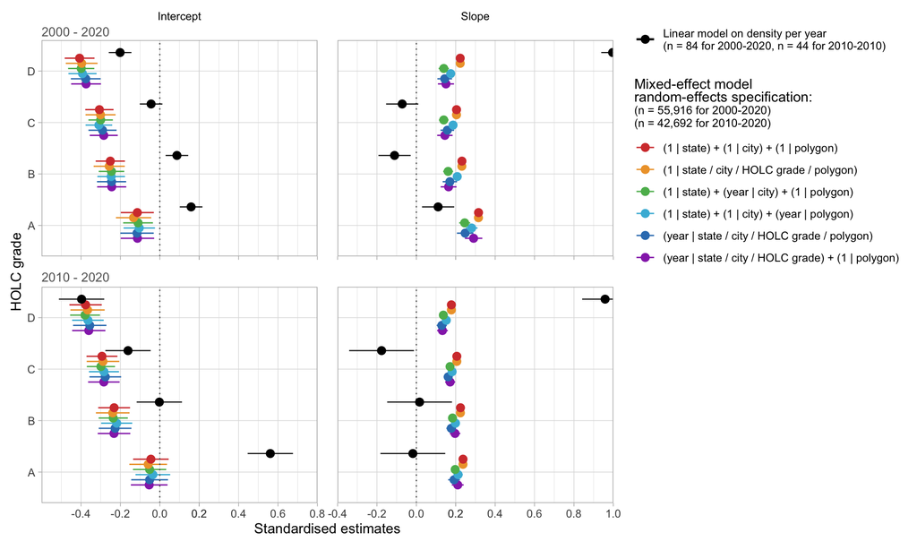

```r
    add_02_break  <- function(lims) sort(unique(c(scales::pretty_breaks()(lims), 0.2)))

    facet_scales <- lapply(seq_len(nrow(rng)), function(i) {
      tl <- rng$type2[i]
      lo <- rng$xmin[i]
      hi <- rng$xmax[i]

      if (grepl("^Slope", tl)) {
        rlang::new_formula(
          lhs = bquote(type2 == .(tl)),
          rhs = scale_x_continuous(
            limits = c(-0.4, 1),
            breaks = add_02_break,
            oob = scales::oob_keep, # keep data for stats, don't drop rows
            expand = expansion(mult = c(0, 0))
          )
        )
      } else if (grepl("^Intercept", tl)) {
        rlang::new_formula(
          lhs = bquote(type2 == .(tl)),
          rhs = scale_x_continuous(
            limits = c(-.6, .8),
            breaks = add_02_break,
            oob = scales::oob_keep,
            expand = expansion(mult = c(0, 0))
          )
        )
      } else {
        rlang::new_formula(
          lhs = bquote(type2 == .(tl)),
          rhs = scale_x_continuous(
            limits = c(lo, hi),
            oob = scales::oob_keep,
            expand = expansion(mult = c(0, 0))
          )
        )
      }
    })

    tr1_adj <- tr1 + ggh4x::facetted_pos_scales(x = facet_scales)
    tr2_adj <- tr2 + ggh4x::facetted_pos_scales(x = facet_scales)

    (tr1_adj / tr2_adj) + plot_layout(axis_titles = "collect") #; ggsave('Output/rev_Fig_Z2_yr-trend_model-compar_D_standardised.png', width= 25, height = 15, units ='cm')
```

**Figure Z2** | Standardised estimates of sampling density between HOLC grades over time. Dots represent estimates (standard deviation of ln-scaled sampling density [Intercepts] per standard deviation of year [slopes]), horizontal lines 95% confidence intervals, colour indicates a random-effects model structure (with variables left from `|` indicating random slopes and right from `|` indicating random intercepts, whereas ‘/’ indicates nested intercepts). The depicted estimates represent true values (as oposed to the contrasts depicted in Fig. Z1) Top row contains estimates for a dataset spanning from 2000 until 2020 (n = 84 sampling densities per grade and year for the linear model, and n = 55,916 sampling densities for each polygon with known area) and bottom row for a dataset from 2010 until 2020 (n = 44 and n = 42,692, respectively).

#### C. visualise predicted relationships

**Figure Z3 | Predictions of sampling density between HOLC grades over time.** In the below figures titles indicate model structures (with terms in parentheses indicating random term: variables left from `|` indicating random slopes and right from `|` indicating random intercepts, whereas ‘/’ indicates nested intercepts). The lines and shaded areas represent predicted relationship between sampling density (km² - right panels, log(km²) - left panels) and year of data collection according to HOLC grade (colour). The first plot in each section (2000-2020 and 2010-2020) is based on a linear model fitted to sampling density for each year (overal number of observations devided by overall HOLC grade area; n = 84 for 2000-2020 and 44 for 2010-2020) and the remaining plots are based on mixed-effect models fitted to samplind density for each HOLC neighbourhood (polygon; n = 55,916 for 2000-2020 and 42,692 for 2010-2020).

##### 2000-2020

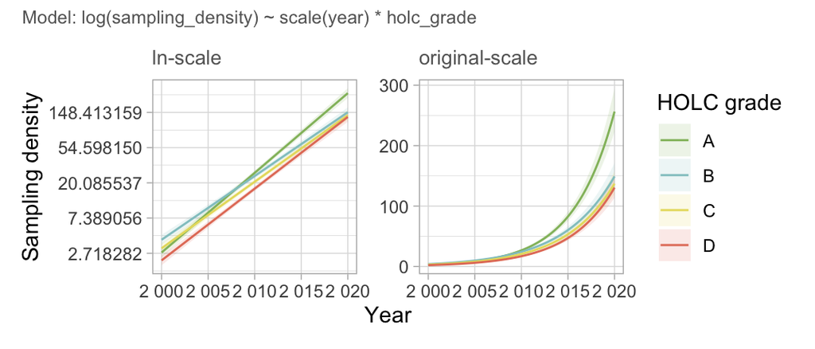

```r
sum_m_  <- lm(log(sampling_density) ~ scale(year)*holc_grade, tt00)
print(plot_effects_holc(sum_m_, tt00, palette = holc_pal, outdir='Output/trend/Oct', save_png = FALSE))
```

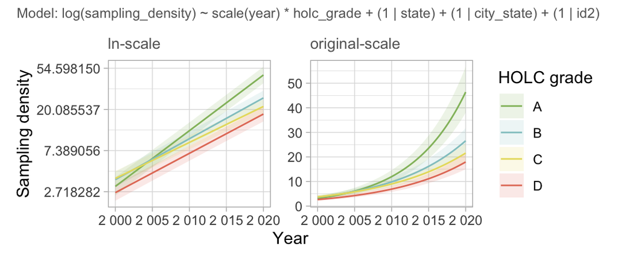

```r
ma = lmer(log(sampling_density) ~ scale(year)*holc_grade +
            (1|state) + (1|city_state) + (1|id2),
            d00)
print(plot_effects_holc(ma, d00, palette = holc_pal, outdir='Output/trend/Oct', save_png = FALSE))
```

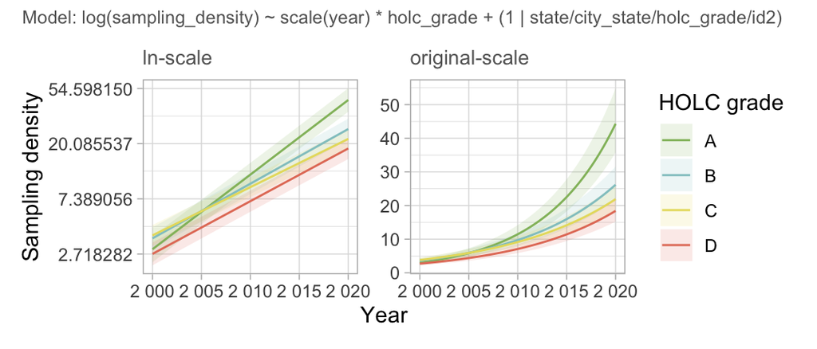

```r
mb = lmer(log(sampling_density) ~ scale(year)*holc_grade +
            (1|state/city_state/holc_grade/id2),
            d00,
            control = lmerControl(
                optimizer = "bobyqa",
                optCtrl = list(maxfun = 2e5)
            )
        )
plot_effects_holc(mb, d00, palette = holc_pal, outdir = 'Output/trend/Oct', save_png = FALSE)
```

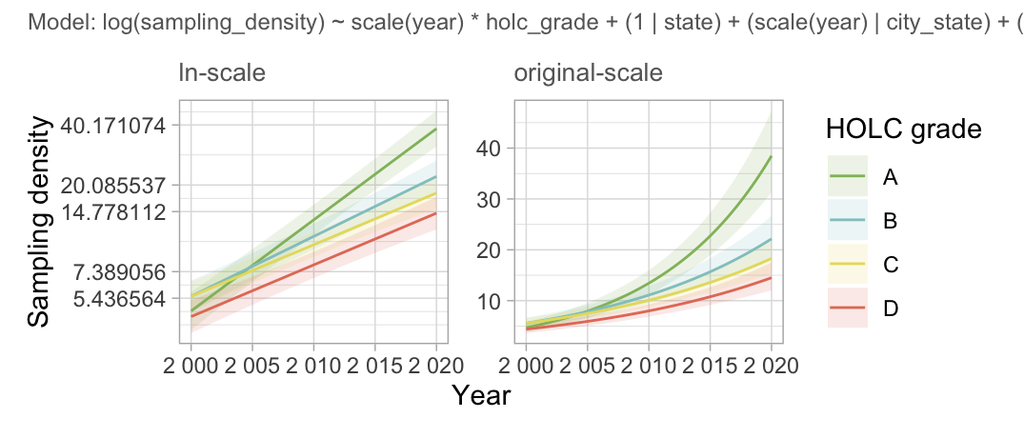

```r
mas1 = lmer(log(sampling_density) ~ scale(year)*holc_grade +
            (1|state) + (scale(year)|city_state) + (1|id2),
            d00,
            control = lmerControl(
                optimizer = "bobyqa",
                optCtrl = list(maxfun = 2e5)
            )
            )
plot_effects_holc(mas1, d00, palette = holc_pal, outdir = 'Output/trend/Oct', save_png = FALSE)
```

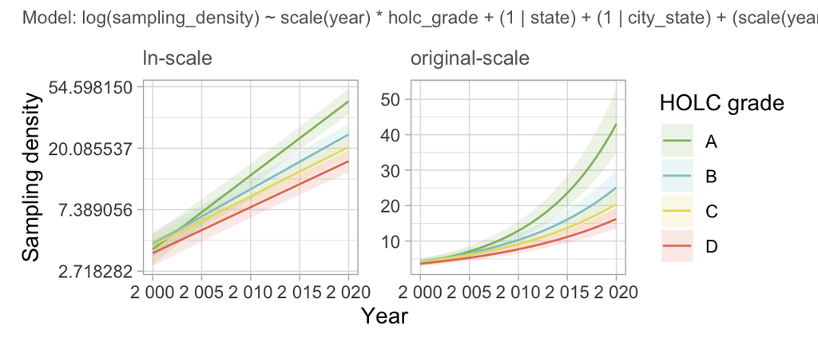

```r
mas2 = lmer(log(sampling_density) ~ scale(year)*holc_grade +
            (1|state) + (1|city_state) + (scale(year)|id2),
            d00,
            control = lmerControl(
                optimizer = "bobyqa",
                optCtrl = list(maxfun = 2e5)
            )
            )
plot_effects_holc(mas2, d00, palette = holc_pal, outdir = 'Output/trend/Oct', save_png = FALSE)
```

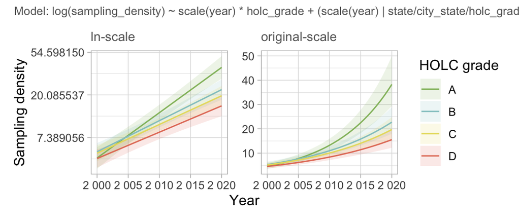

```r
mbs1 = lmer(log(sampling_density) ~ scale(year)*holc_grade +
            (scale(year)|state/city_state/holc_grade/id2),
            d00,
            control = lmerControl(
                optimizer = "bobyqa",
                optCtrl = list(maxfun = 2e5)
            )
            )
plot_effects_holc(mbs1, d00, palette = holc_pal, outdir = 'Output/trend/Oct', save_png = FALSE)
```

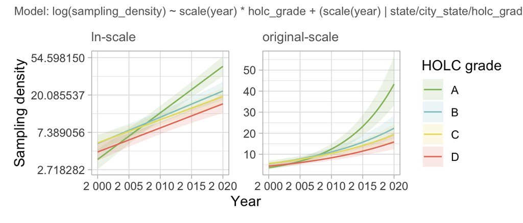

```r
msab1 = lmer(log(sampling_density) ~ scale(year)*holc_grade +
            (scale(year)|state/city_state/holc_grade) + (1|id2),
            d00,
            control = lmerControl(
                optimizer = "bobyqa",
                optCtrl = list(maxfun = 2e5)
            )
            )
plot_effects_holc(msab1, d00, palette = holc_pal, outdir = 'Output/trend/Oct', save_png = FALSE)
```

##### 2010-2020

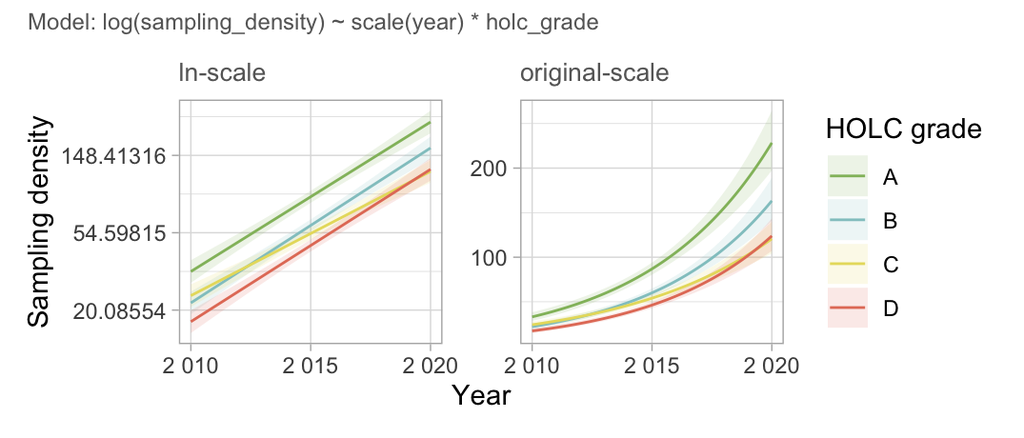

```r
sum_m_10  <- lm(log(sampling_density) ~ scale(year)*holc_grade, tt10)
print(plot_effects_holc(sum_m_10, tt10, palette = holc_pal, outdir='Output/trend/Oct', save_png = FALSE))
```

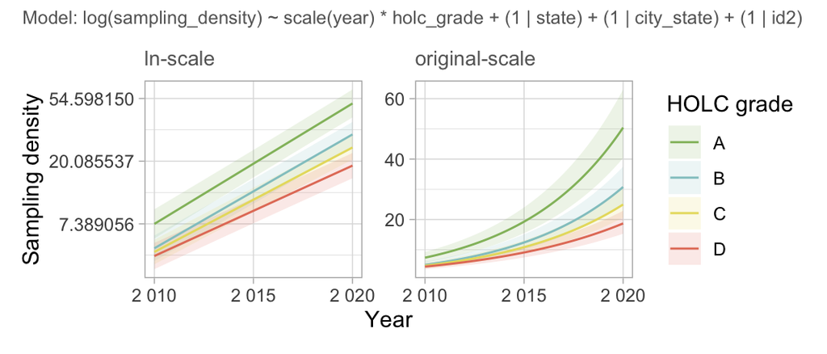

```r
ma_ = lmer(log(sampling_density) ~ scale(year)*holc_grade +
            (1|state) + (1|city_state) + (1|id2),
            d10,
            control = lmerControl(
                optimizer = "bobyqa",
                optCtrl = list(maxfun = 2e5)
            )
        )
plot_effects_holc(ma_, d10, palette = holc_pal, outdir='Output/trend/Oct', ver ='v1_10-20', save_png = FALSE)
```

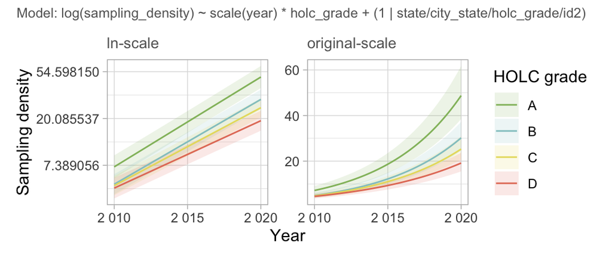

```r
mb_ = lmer(log(sampling_density) ~ scale(year)*holc_grade +
            (1|state/city_state/holc_grade/id2),
            d10,
            control = lmerControl(
                optimizer = "bobyqa",
                optCtrl = list(maxfun = 2e5)
            )
        )
plot_effects_holc(mb_, d10, palette = holc_pal, outdir = 'Output/trend/Oct', ver ='v1_10-20', save_png = FALSE)
```

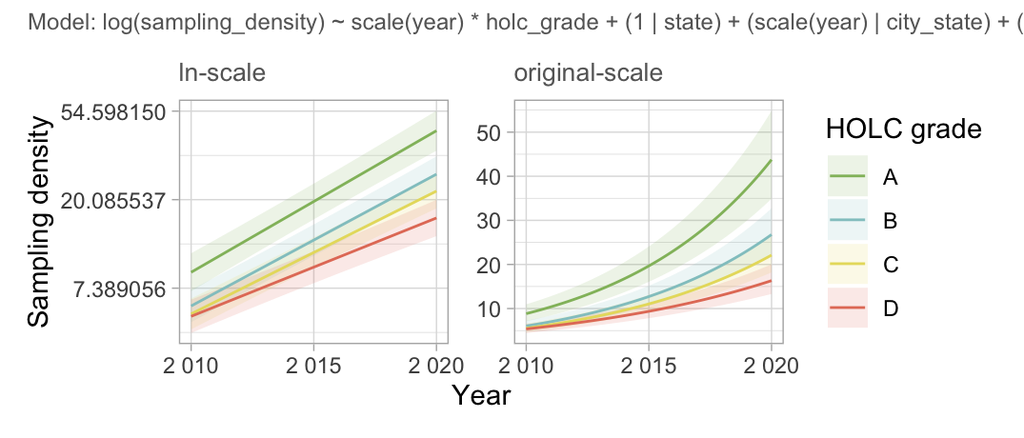

```r
mas1_ = lmer(log(sampling_density) ~ scale(year)*holc_grade +
            (1|state) + (scale(year)|city_state) + (1|id2),
            d10,
            control = lmerControl(
                optimizer = "bobyqa",
                optCtrl = list(maxfun = 2e5)
            )
            )
plot_effects_holc(mas1_, d10, palette = holc_pal, outdir = 'Output/trend/Oct', ver ='v1_10-20')
```

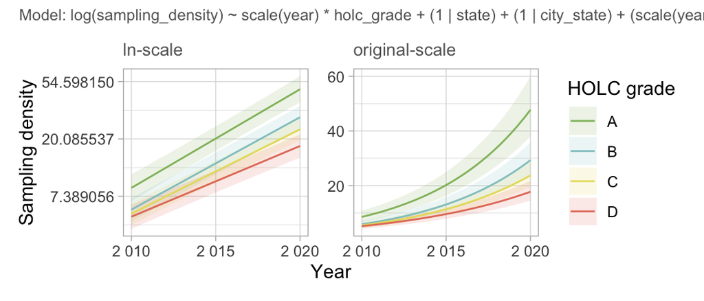

```r
mas2_ = lmer(log(sampling_density) ~ scale(year)*holc_grade +
            (1|state) + (1|city_state) + (scale(year)|id2),
            d10,
            control = lmerControl(
                optimizer = "bobyqa",
                optCtrl = list(maxfun = 2e5)
            )
            )
plot_effects_holc(mas2_, d10, palette = holc_pal, outdir = 'Output/trend/Oct', ver ='v1_10-20', save_png = FALSE)
```

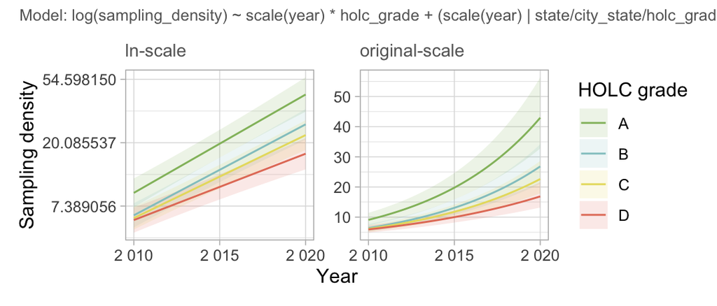

```r
mbs1_ = lmer(log(sampling_density) ~ scale(year)*holc_grade +
            (scale(year)|state/city_state/holc_grade/id2),
            d10,
            control = lmerControl(
                optimizer = "bobyqa",
                optCtrl = list(maxfun = 2e5)
            )
            )
plot_effects_holc(mbs1_, d10, palette = holc_pal, outdir = 'Output/trend/Oct', ver ='v1_10-20', save_png = FALSE)
```

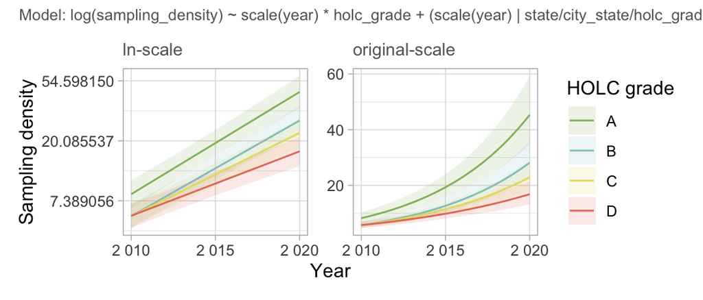

```r
msab1_ = lmer(log(sampling_density) ~ scale(year)*holc_grade +
            (scale(year)|state/city_state/holc_grade) + (1|id2),
            d10,
            control = lmerControl(
                optimizer = "bobyqa",
                optCtrl = list(maxfun = 2e5)
            )
            )
plot_effects_holc(msab1_, d10, palette = holc_pal, outdir = 'Output/trend/Oct', ver ='v1_10-20', save_png = FALSE)
```

# References

Akaike, Hirotugu. 2025. “Akaike’s Information Criterion.” In *International Encyclopedia of Statistical Science*, edited by Miodrag Lovric, 41–42. Berlin, Heidelberg: Springer Berlin Heidelberg. https://doi.org/10.1007/978-3-662-69359-9_14.

Ellis-Soto, Diego, Melissa Chapman, and Dexter H. Locke. 2023. “Historical Redlining Is Associated with Increasing Geographical Disparities in Bird Biodiversity Sampling in the United States.” *Nat Hum Behav* 7 (11): 1869–77. https://doi.org/10.1038/s41562-023-01688-5.

# Session info

**Table S2 | System session info.**

```r
df_session_platform <- devtools::session_info()$platform %>%
    unlist(.) %>%
    as.data.frame(.) %>%
    tibble::rownames_to_column(.)

colnames(df_session_platform) <- c("Item", "Value")

df_session_platform %>%
  kableExtra::kbl(align=c('r', 'l'), linesep = "") %>%
  kableExtra::kable_paper(c("striped", "condensed"), full_width = F, position = "left")
```

| Item | Value |
| --- | --- |
| version | R version 4.2.0 (2022-04-22) |
| os | macOS Mojave 10.14.6 |
| system | x86_64, darwin17.0 |
| ui | X11 |
| language | (EN) |
| collate | en_GB.UTF-8 |
| ctype | en_GB.UTF-8 |
| tz | Europe/Prague |
| date | 2025-10-16 |
| pandoc | 2.7.2 @ /usr/local/bin/ (via rmarkdown) |

**Table S3 | Info about used packages.**

```r
df_session_packages <- devtools::session_info()$packages %>%
    as.data.frame(.) %>%
    # filter(attached == TRUE) %>%
    dplyr::select(loadedversion, date, source) %>%
    tibble::rownames_to_column()

colnames(df_session_packages) <- c("Package", "Loaded version", "Date", "Source")
df_session_packages %>%
    kableExtra::kbl(align = c("l", "l","l","l"), linesep = "") %>%
    kableExtra::kable_paper(c("striped", "condensed"), full_width = F, position = "left") %>%
        kableExtra::scroll_box(width = "90%", height = "350px")
```

| Package | Loaded version | Date | Source |
| --- | --- | --- | --- |
| backports | 1.5.0 | 2024-05-23 | CRAN (R 4.2.0) |
| bayestestR | 0.13.1 | 2023-04-07 | CRAN (R 4.2.0) |
| bit | 4.0.5 | 2022-11-15 | CRAN (R 4.2.0) |
| bit64 | 4.0.5 | 2020-08-30 | CRAN (R 4.2.0) |
| boot | 1.3-28.1 | 2022-11-22 | CRAN (R 4.2.0) |
| broom | 1.0.7 | 2024-09-26 | CRAN (R 4.2.0) |
| bslib | 0.8.0 | 2024-07-29 | CRAN (R 4.2.0) |
| cachem | 1.1.0 | 2024-05-16 | CRAN (R 4.2.0) |
| callr | 3.7.3 | 2022-11-02 | CRAN (R 4.2.0) |
| carData | 3.0-5 | 2022-01-06 | CRAN (R 4.2.0) |
| class | 7.3-22 | 2023-05-03 | CRAN (R 4.2.0) |
| classInt | 0.4-10 | 2023-09-05 | CRAN (R 4.2.0) |
| cli | 3.6.5 | 2025-04-23 | CRAN (R 4.2.0) |
| clisymbols | 1.2.0 | 2017-05-21 | CRAN (R 4.2.0) |
| coda | 0.19-4 | 2020-09-30 | CRAN (R 4.2.0) |
| codetools | 0.2-19 | 2023-02-01 | CRAN (R 4.2.0) |
| colorspace | 2.1-1 | 2024-07-26 | CRAN (R 4.2.0) |
| commonmark | 1.9.5 | 2025-03-17 | CRAN (R 4.2.0) |
| cowplot | 1.1.3 | 2024-01-22 | CRAN (R 4.2.0) |
| crayon | 1.5.2 | 2022-09-29 | CRAN (R 4.2.0) |
| data.table | 1.16.2 | 2024-10-10 | CRAN (R 4.2.0) |
| datawizard | 0.9.0 | 2023-09-15 | CRAN (R 4.2.0) |
| DBI | 1.1.3 | 2022-06-18 | CRAN (R 4.2.0) |
| devtools | 2.4.5 | 2022-10-11 | CRAN (R 4.2.0) |
| dichromat | 2.0-0.1 | 2022-05-02 | CRAN (R 4.2.0) |
| digest | 0.6.37 | 2024-08-19 | CRAN (R 4.2.0) |
| dplyr | 1.1.4 | 2023-11-17 | CRAN (R 4.2.0) |
| e1071 | 1.7-13 | 2023-02-01 | CRAN (R 4.2.0) |
| effects | 4.2-2 | 2022-07-13 | CRAN (R 4.2.0) |
| effectsize | 0.8.6 | 2023-09-14 | CRAN (R 4.2.0) |

[output cut: 120 more lines]